# MovieLens Answers

### `Project - MovieLens Data Analysis`

The GroupLens Research Project is a research group in the Department of Computer Science and Engineering at the University of Minnesota. The data is widely used for collaborative filtering and other filtering solutions. However, we will be using this data to act as a means to demonstrate our skill in using Python to “play” with data.

### `Objective:`

- To implement the techniques learnt as a part of the course.

### `Datasets Information:`

*rating.csv:* It contains information on ratings given by the users to a particular movie.

- user id: id assigned to every user
- movie id: id assigned to every movie
- rating: rating given by the user
- timestamp: Time recorded when the user gave a rating

*movie.csv:* File contains information related to the movies and their genre.

- movie id: id assigned to every movie
- movie title: Title of the movie
- release date: Date of release of the movie
- Action: Genre containing binary values (1 - for action 0 - not action)
- Adventure: Genre containing binary values (1 - for adventure 0 - not adventure)
- Animation: Genre containing binary values (1 - for animation 0 - not animation)
- Children’s: Genre containing binary values (1 - for children's 0 - not children's)
- Comedy: Genre containing binary values (1 - for comedy 0 - not comedy)
- Crime: Genre containing binary values (1 - for crime 0 - not crime)
- Documentary: Genre containing binary values (1 - for documentary 0 - not documentary)
- Drama: Genre containing binary values (1 - for drama 0 - not drama)
- Fantasy: Genre containing binary values (1 - for fantasy 0 - not fantasy)
- Film-Noir: Genre containing binary values (1 - for film-noir 0 - not film-noir)
- Horror: Genre containing binary values (1 - for horror 0 - not horror)
- Musical: Genre containing binary values (1 - for musical 0 - not musical)
- Mystery: Genre containing binary values (1 - for mystery 0 - not mystery)
- Romance: Genre containing binary values (1 - for romance 0 - not romance)
- Sci-Fi: Genre containing binary values (1 - for sci-fi 0 - not sci-fi)
- Thriller: Genre containing binary values (1 - for thriller 0 - not thriller)
- War: Genre containing binary values (1 - for war 0 - not war)
- Western: Genre containing binary values (1 - for western - not western)

*user.csv:* It contains information of the users who have rated the movies.

- user id: id assigned to every user
- age: Age of the user
- gender: Gender of the user
- occupation: Occupation of the user
- zip code: Zip code of the use

**`Please provide your insights wherever necessary.`**

### `Learning Outcomes:`

- Exploratory Data Analysis
- Visualization using Python
- Pandas – groupby, merging

### `Domain`

- Internet and Entertainment

**Note that the project will need you to apply the concepts of groupby and merging extensively.**

### 1. Import the necessary packages - 2.5 marks

```python
import csv
import numpy as np
import pandas as pd
import matplotlib.pyplot as plt
import seaborn as sns
import warnings
warnings.filterwarnings("ignore")
from PIL import Image
from datetime import datetime
%matplotlib inline
plt.rcParams["figure.figsize"] = [10, 5]
```

### 2. Read the 3 datasets into dataframes - 2.5 marks

```python
# userdf - dataframe from users.csv
userdf = pd.read_csv("user.csv")
# itemdf - dataframe from item.csv
itemdf = pd.read_csv("item.csv")
# datadf - dataframe from data.csv
datadf = pd.read_csv('data.csv')
```

### 3. Apply info, shape, describe, and find the number of missing values in the data. Present at least 3 observations from these operations - 2.5 marks

- Note that you will need to do it for all the three datasets seperately

```python
print(userdf.shape)
print(userdf.describe)
print(userdf.info())
print(userdf[userdf.isnull()])
print(userdf.isnull().sum())
```

```
(943, 5)
<bound method NDFrame.describe of      user id  age gender     occupation zip code
0          1   24      M     technician    85711
1          2   53      F          other    94043
2          3   23      M         writer    32067
3          4   24      M     technician    43537
4          5   33      F          other    15213
..       ...  ...    ...            ...      ...
938      939   26      F        student    33319
939      940   32      M  administrator    02215
940      941   20      M        student    97229
941      942   48      F      librarian    78209
942      943   22      M        student    77841

[943 rows x 5 columns]>
<class 'pandas.core.frame.DataFrame'>
RangeIndex: 943 entries, 0 to 942
Data columns (total 5 columns):
 #   Column      Non-Null Count  Dtype
---  ------      --------------  -----
 0   user id     943 non-null    int64
 1   age         943 non-null    int64
 2   gender      943 non-null    object
 3   occupation  943 non-null    object
 4   zip code    943 non-null    object
dtypes: int64(2), object(3)
memory usage: 37.0+ KB
None
     user id  age gender occupation zip code
0        NaN  NaN    NaN        NaN      NaN
1        NaN  NaN    NaN        NaN      NaN
2        NaN  NaN    NaN        NaN      NaN
3        NaN  NaN    NaN        NaN      NaN
4        NaN  NaN    NaN        NaN      NaN
..       ...  ...    ...        ...      ...
938      NaN  NaN    NaN        NaN      NaN
939      NaN  NaN    NaN        NaN      NaN
940      NaN  NaN    NaN        NaN      NaN
941      NaN  NaN    NaN        NaN      NaN
942      NaN  NaN    NaN        NaN      NaN

[943 rows x 5 columns]
user id       0
age           0
gender        0
occupation    0
zip code      0
dtype: int64
```

```python
print(itemdf.shape)
print(itemdf.describe())
print(itemdf.info())
print(itemdf[itemdf.isnull()])
print(itemdf.isnull().sum())
```

```
(1681, 22)
          movie id      unknown       Action    Adventure    Animation  \
count  1681.000000  1681.000000  1681.000000  1681.000000  1681.000000
mean    841.841761     0.000595     0.149316     0.080309     0.024985
std     485.638077     0.024390     0.356506     0.271852     0.156126
min       1.000000     0.000000     0.000000     0.000000     0.000000
25%     422.000000     0.000000     0.000000     0.000000     0.000000
50%     842.000000     0.000000     0.000000     0.000000     0.000000
75%    1262.000000     0.000000     0.000000     0.000000     0.000000
max    1682.000000     1.000000     1.000000     1.000000     1.000000

         Childrens       Comedy        Crime  Documentary        Drama  \
count  1681.000000  1681.000000  1681.000000  1681.000000  1681.000000
mean      0.072576     0.300416     0.064842     0.029744     0.431291
std       0.259516     0.458576     0.246321     0.169931     0.495404
min       0.000000     0.000000     0.000000     0.000000     0.000000
25%       0.000000     0.000000     0.000000     0.000000     0.000000
50%       0.000000     0.000000     0.000000     0.000000     0.000000
75%       0.000000     1.000000     0.000000     0.000000     1.000000
max       1.000000     1.000000     1.000000     1.000000     1.000000

           Fantasy    Film-Noir       Horror      Musical      Mystery  \
count  1681.000000  1681.000000  1681.000000  1681.000000  1681.000000
mean      0.013087     0.014277     0.054729     0.033314     0.036288
std       0.113683     0.118667     0.227519     0.179507     0.187061
min       0.000000     0.000000     0.000000     0.000000     0.000000
25%       0.000000     0.000000     0.000000     0.000000     0.000000
50%       0.000000     0.000000     0.000000     0.000000     0.000000
75%       0.000000     0.000000     0.000000     0.000000     0.000000
max       1.000000     1.000000     1.000000     1.000000     1.000000

           Romance       Sci-Fi     Thriller          War      Western
count  1681.000000  1681.000000  1681.000000  1681.000000  1681.000000
mean      0.146936     0.060083     0.149316     0.042237     0.016062
std       0.354148     0.237712     0.356506     0.201189     0.125751
min       0.000000     0.000000     0.000000     0.000000     0.000000
25%       0.000000     0.000000     0.000000     0.000000     0.000000
50%       0.000000     0.000000     0.000000     0.000000     0.000000
75%       0.000000     0.000000     0.000000     0.000000     0.000000
max       1.000000     1.000000     1.000000     1.000000     1.000000
```

[output cut: 78 more lines]

```
Comedy          0
Crime           0
Documentary     0
Drama           0
Fantasy         0
Film-Noir       0
Horror          0
Musical         0
Mystery         0
Romance         0
Sci-Fi          0
Thriller        0
War             0
Western         0
dtype: int64
```

```python
print(datadf.shape)
print(datadf.describe())
print(datadf.info())
print(datadf[datadf.isnull()])
print(datadf.isnull().sum())
```

```
(100000, 4)
            user id       movie id         rating     timestamp
count  100000.00000  100000.000000  100000.000000  1.000000e+05
mean      462.48475     425.530130       3.529860  8.835289e+08
std       266.61442     330.798356       1.125674  5.343856e+06
min         1.00000       1.000000       1.000000  8.747247e+08
25%       254.00000     175.000000       3.000000  8.794487e+08
50%       447.00000     322.000000       4.000000  8.828269e+08
75%       682.00000     631.000000       4.000000  8.882600e+08
max       943.00000    1682.000000       5.000000  8.932866e+08
<class 'pandas.core.frame.DataFrame'>
RangeIndex: 100000 entries, 0 to 99999
Data columns (total 4 columns):
 #   Column     Non-Null Count   Dtype
---  ------     --------------   -----
 0   user id    100000 non-null  int64
 1   movie id   100000 non-null  int64
 2   rating     100000 non-null  int64
 3   timestamp  100000 non-null  int64
dtypes: int64(4)
memory usage: 3.1 MB
None
       user id  movie id  rating  timestamp
0          NaN       NaN     NaN        NaN
1          NaN       NaN     NaN        NaN
2          NaN       NaN     NaN        NaN
3          NaN       NaN     NaN        NaN
4          NaN       NaN     NaN        NaN
...        ...       ...     ...        ...
99995      NaN       NaN     NaN        NaN
99996      NaN       NaN     NaN        NaN
99997      NaN       NaN     NaN        NaN
99998      NaN       NaN     NaN        NaN
99999      NaN       NaN     NaN        NaN

[100000 rows x 4 columns]
user id      0
movie id     0
rating       0
timestamp    0
dtype: int64
```

**Observations:**

1. In item csv - there is unknown Genre.
2. Item csv, data csv and user csv don't have null values.

### 4. Find the number of movies per genre using the item data - 2.5 marks

```python
print(itemdf.columns)
genreList = ['unknown', 'Action',
       'Adventure', 'Animation', 'Childrens', 'Comedy', 'Crime', 'Documentary',
       'Drama', 'Fantasy', 'Film-Noir', 'Horror', 'Musical', 'Mystery',
       'Romance', 'Sci-Fi', 'Thriller', 'War', 'Western']
print(itemdf[genreList].sum())
```

```
Index(['movie id', 'movie title', 'release date', 'unknown', 'Action',
       'Adventure', 'Animation', 'Childrens', 'Comedy', 'Crime', 'Documentary',
       'Drama', 'Fantasy', 'Film-Noir', 'Horror', 'Musical', 'Mystery',
       'Romance', 'Sci-Fi', 'Thriller', 'War', 'Western'],
      dtype='object')
unknown          1
Action         251
Adventure      135
Animation       42
Childrens      122
Comedy         505
Crime          109
Documentary     50
Drama          725
Fantasy         22
Film-Noir       24
Horror          92
Musical         56
Mystery         61
Romance        247
Sci-Fi         101
Thriller       251
War             71
Western         27
dtype: int64
```

**Insights:**

1. From item dataframe columns, derived the genrelist using column command.
2. Used genreList with itemdf and derived sum for each genre.
3. Drama - 725 most number of movies available.
4. Comedy - 505 Second most available movie.
5. Unknown - 1 There is one unknown Genre.

### 5. Drop the movie where the genre is unknown - 2.5 marks

```python
itemdf.drop("unknown",axis=1,inplace=True)
```

**Insights:**

### 6. Find the movies that have more than one genre - 5 marks

hint: use sum on the axis = 1

Display movie name, number of genres for the movie in dataframe

and also print(total number of movies which have more than one genres)

```python
# genreList is declared earlier
genreList = ['Action',
       'Adventure', 'Animation', 'Childrens', 'Comedy', 'Crime', 'Documentary',
       'Drama', 'Fantasy', 'Film-Noir', 'Horror', 'Musical', 'Mystery',
       'Romance', 'Sci-Fi', 'Thriller', 'War', 'Western']

# Adding Genre given a movie
itemdf['no_of_genre'] = itemdf[genreList].sum(axis=1)


print ("**********************************************************************************************")
# Printing the maximum number of genre given a movie
print("Maxium number of genre given a movie is :: %s"%itemdf['no_of_genre'].max())
print ("**********************************************************************************************")


# Printing the movie title which has maximum number of genre
maxitemdf = itemdf[itemdf['no_of_genre'] == itemdf['no_of_genre'].max()]
print(maxitemdf[['movie title','no_of_genre']])
print ("**********************************************************************************************")

# Printing the movie title which has maximum number of genre
print(itemdf[itemdf['no_of_genre'] > 1 ][['movie title','no_of_genre']])
print ("**********************************************************************************************")
```

```
Maxium number of genre given a movie is :: 6
                        movie title  no_of_genre
171       Empire Strikes Back, The             6
424   Transformers: The Movie, The             6
558  Kid in King Arthur's Court, A             6
             movie title  no_of_genre
0             Toy Story             3
1             GoldenEye             3
3            Get Shorty             3
4               Copycat             3
6        Twelve Monkeys             2
...                  ...          ...
1667  MURDER and murder             3
1668            Tainted             2
1671             Mirage             2
1677          B. Monkey             2
1678      Sliding Doors             2

[849 rows x 2 columns]
```

**Insights:**

1. Adding Genre given a movie and added a new column no_of_genre.
2. Using max function on no_of_genre got the maximum number of genre and it is 6.
3. There are three moview with total no_of_genre as 6.
4. there are 849 movies which has been classfied more than one genre.

### 7. Univariate plots of columns: 'rating', 'Age', 'release year', 'Gender' and 'Occupation' - 10 marks

*HINT: Use distplot for age and countplot for release year, ratings,*

*HINT: Please refer to the below snippet to understand how to get to release year from release date. You can use str.split() as depicted below or you could convert it to pandas datetime format and extract year (.dt.year)*

```python
print(datadf.columns)
print(itemdf.columns)
print(userdf.columns)
print ("**********************************************************************************************")
print(" Merging datadf and itemdf with movie id as common")
dataItemDF = pd.merge(datadf,itemdf,how='outer',on='movie id',sort=False)
print(dataItemDF)
print ("**********************************************************************************************")

print(" Merging userdf and other combined df with user id as common")
print ("**********************************************************************************************")
userDataItemDF = pd.merge(dataItemDF,userdf,how='outer',on='user id',sort=False)
print(userDataItemDF)
print ("**********************************************************************************************")

def get_year(s):
    return datetime.strftime(s,'%a')

userDataItemDF['release_date'] = pd.to_datetime(userDataItemDF['release date'])

userDataItemDF['release_year'] = userDataItemDF['release_date'].dt.year

userDataItemDF
```

```
Index(['user id', 'movie id', 'rating', 'timestamp'], dtype='object')
Index(['movie id', 'movie title', 'release date', 'Action', 'Adventure',
       'Animation', 'Childrens', 'Comedy', 'Crime', 'Documentary', 'Drama',
       'Fantasy', 'Film-Noir', 'Horror', 'Musical', 'Mystery', 'Romance',
       'Sci-Fi', 'Thriller', 'War', 'Western', 'no_of_genre'],
      dtype='object')
Index(['user id', 'age', 'gender', 'occupation', 'zip code'], dtype='object')
 Merging datadf and itemdf with movie id as common
       user id  movie id  rating  timestamp  \
0          196       242       3  881250949
1           63       242       3  875747190
2          226       242       5  883888671
3          154       242       3  879138235
4          306       242       5  876503793
...        ...       ...     ...        ...
```

[output cut: 100 more lines]

|  | user id | movie id | rating | timestamp | movie title | release date | Action | Adventure | Animation | Childrens | ... | Thriller | War | Western | no_of_genre | age | gender | occupation | zip code | release_date | release_year |
| --- | --- | --- | --- | --- | --- | --- | --- | --- | --- | --- | --- | --- | --- | --- | --- | --- | --- | --- | --- | --- | --- |
| 0 | 196 | 242 | 3 | 881250949 | Kolya | 24-Jan-1997 | 0.0 | 0.0 | 0.0 | 0.0 | ... | 0.0 | 0.0 | 0.0 | 1.0 | 49 | M | writer | 55105 | 1997-01-24 | 1997.0 |
| 1 | 196 | 257 | 2 | 881251577 | Men in Black | 04-Jul-1997 | 1.0 | 1.0 | 0.0 | 0.0 | ... | 0.0 | 0.0 | 0.0 | 4.0 | 49 | M | writer | 55105 | 1997-07-04 | 1997.0 |
| 2 | 196 | 111 | 4 | 881251793 | Truth About Cats & Dogs, The | 26-Apr-1996 | 0.0 | 0.0 | 0.0 | 0.0 | ... | 0.0 | 0.0 | 0.0 | 2.0 | 49 | M | writer | 55105 | 1996-04-26 | 1996.0 |
| 3 | 196 | 25 | 4 | 881251955 | Birdcage, The | 08-Mar-1996 | 0.0 | 0.0 | 0.0 | 0.0 | ... | 0.0 | 0.0 | 0.0 | 1.0 | 49 | M | writer | 55105 | 1996-03-08 | 1996.0 |
| 4 | 196 | 382 | 4 | 881251843 | Adventures of Priscilla, Queen of the Desert, ... | 01-Jan-1994 | 0.0 | 0.0 | 0.0 | 0.0 | ... | 0.0 | 0.0 | 0.0 | 2.0 | 49 | M | writer | 55105 | 1994-01-01 | 1994.0 |
| ... | ... | ... | ... | ... | ... | ... | ... | ... | ... | ... | ... | ... | ... | ... | ... | ... | ... | ... | ... | ... | ... |
| 99995 | 873 | 313 | 5 | 891392177 | Titanic | 01-Jan-1997 | 1.0 | 0.0 | 0.0 | 0.0 | ... | 0.0 | 0.0 | 0.0 | 3.0 | 48 | F | administrator | 33763 | 1997-01-01 | 1997.0 |
| 99996 | 873 | 326 | 4 | 891392656 | G.I. Jane | 01-Jan-1997 | 1.0 | 0.0 | 0.0 | 0.0 | ... | 0.0 | 1.0 | 0.0 | 3.0 | 48 | F | administrator | 33763 | 1997-01-01 | 1997.0 |
| 99997 | 873 | 348 | 3 | 891392577 | Desperate Measures | 30-Jan-1998 | 0.0 | 0.0 | 0.0 | 0.0 | ... | 1.0 | 0.0 | 0.0 | 3.0 | 48 | F | administrator | 33763 | 1998-01-30 | 1998.0 |
| 99998 | 873 | 358 | 2 | 891392698 | Spawn | 01-Aug-1997 | 1.0 | 1.0 | 0.0 | 0.0 | ... | 1.0 | 0.0 | 0.0 | 4.0 | 48 | F | administrator | 33763 | 1997-08-01 | 1997.0 |
| 99999 | 873 | 342 | 4 | 891392698 | Man Who Knew Too Little, The | 01-Jan-1997 | 0.0 | 0.0 | 0.0 | 0.0 | ... | 0.0 | 0.0 | 0.0 | 2.0 | 48 | F | administrator | 33763 | 1997-01-01 | 1997.0 |

100000 rows × 31 columns

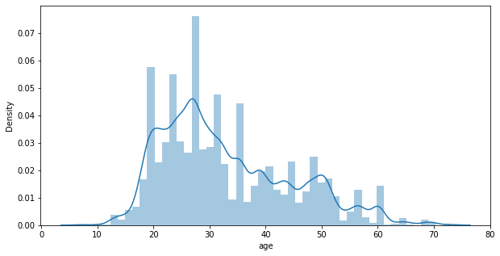

```python
sns.distplot(userDataItemDF['age'])
```

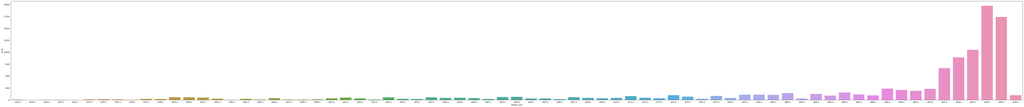

```python
plt.rcParams["figure.figsize"] = [100, 10]
sns.countplot(userDataItemDF["release_year"])
```

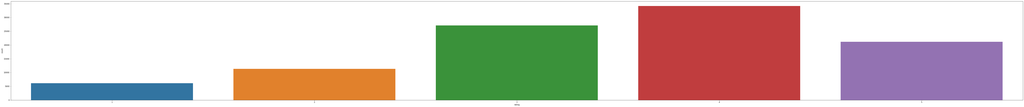

```python
sns.countplot(userDataItemDF["rating"])
```

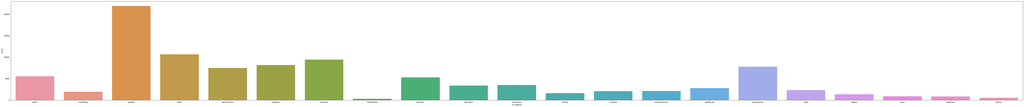

```python
sns.countplot(userDataItemDF["occupation"])
```

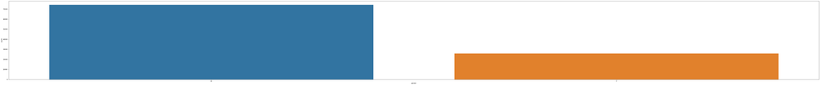

```python
sns.countplot(userDataItemDF["gender"])
```

### 8. Visualize how popularity of genres has changed over the years - 10 marks

Note that you need to use the **percent of number of releases in a year** as a parameter of popularity of a genre

Hint 1: You need to reach to a data frame where the release year is the index and the genre is the column names (one cell shows the number of release in a year in one genre) or vice versa. (Drop unnecessary column if there are any)

Hint 2: Find the total number of movies release in a year(use item dataset to get count of movies released in a particular year, store that value in a new column as 'total'). Now divide the value of each genre in that year by total to get percentage number of release in a particular year. `(df.div(df['total'], axis= 0) * 100)`

Once that is achieved, you can either use univariate plots or can use the heatmap to visualise all the changes over the years in one go.

Hint 3: Use groupby on the relevant column and use sum() on the same to find out the number of releases in a year/genre.

```python
itemdf2 = itemdf.copy()

# renaming and Splitting release date to get year and added to a column
itemdf2['release_date'] = pd.to_datetime(itemdf2['release date'])

itemdf2['release_year'] = itemdf2['release_date'].dt.year
itemdf2.columns

# Dropping the columns of not intrest
itemdf2.drop(['movie id', 'movie title', 'release date','no_of_genre', 'release_date'],axis=1,inplace=True)
itemdf2.set_index('release_year',inplace=True)

print(itemdf2.info())
itemdf2.sort_index(inplace=True)
```

```
<class 'pandas.core.frame.DataFrame'>
Int64Index: 1681 entries, 1995 to 1996
Data columns (total 18 columns):
 #   Column       Non-Null Count  Dtype
---  ------       --------------  -----
 0   Action       1681 non-null   int64
 1   Adventure    1681 non-null   int64
 2   Animation    1681 non-null   int64
 3   Childrens    1681 non-null   int64
 4   Comedy       1681 non-null   int64
 5   Crime        1681 non-null   int64
 6   Documentary  1681 non-null   int64
 7   Drama        1681 non-null   int64
 8   Fantasy      1681 non-null   int64
 9   Film-Noir    1681 non-null   int64
 10  Horror       1681 non-null   int64
 11  Musical      1681 non-null   int64
 12  Mystery      1681 non-null   int64
 13  Romance      1681 non-null   int64
 14  Sci-Fi       1681 non-null   int64
 15  Thriller     1681 non-null   int64
 16  War          1681 non-null   int64
 17  Western      1681 non-null   int64
dtypes: int64(18)
memory usage: 249.5 KB
None
```

```python
# Based on year suming the genres
itemdf3 = itemdf2[['Action', 'Adventure', 'Animation', 'Childrens',
       'Comedy', 'Crime', 'Documentary', 'Drama', 'Fantasy', 'Film-Noir',
       'Horror', 'Musical', 'Mystery', 'Romance', 'Sci-Fi', 'Thriller', 'War',
       'Western']].groupby('release_year').sum()

# Adding column total to get total genres in an year.
itemdf3['total'] = itemdf3[['Action', 'Adventure', 'Animation', 'Childrens',
       'Comedy', 'Crime', 'Documentary', 'Drama', 'Fantasy', 'Film-Noir',
       'Horror', 'Musical', 'Mystery', 'Romance', 'Sci-Fi', 'Thriller', 'War',
       'Western']].sum(axis=1)

# Getting the % of Genre to total movies released
print("Getting the % of Genre to total movies released")
itemdf4 = itemdf3.div(itemdf3['total'], axis= 0) * 100


itemdf4.reset_index(inplace=True)
itemdf4
```

```
Getting the % of Genre to total movies released
```

|  | release_year | Action | Adventure | Animation | Childrens | Comedy | Crime | Documentary | Drama | Fantasy | Film-Noir | Horror | Musical | Mystery | Romance | Sci-Fi | Thriller | War | Western | total |
| --- | --- | --- | --- | --- | --- | --- | --- | --- | --- | --- | --- | --- | --- | --- | --- | --- | --- | --- | --- | --- |
| 0 | 1922 | 0.000000 | 0.000000 | 0.000000 | 0.000000 | 0.000000 | 0.000000 | 0.000000 | 0.000000 | 0.000000 | 0.000000 | 100.000000 | 0.000000 | 0.000000 | 0.000000 | 0.000000 | 0.000000 | 0.000000 | 0.000000 | 100.0 |
| 1 | 1926 | 0.000000 | 0.000000 | 0.000000 | 0.000000 | 0.000000 | 0.000000 | 0.000000 | 100.000000 | 0.000000 | 0.000000 | 0.000000 | 0.000000 | 0.000000 | 0.000000 | 0.000000 | 0.000000 | 0.000000 | 0.000000 | 100.0 |
| 2 | 1930 | 0.000000 | 0.000000 | 0.000000 | 0.000000 | 0.000000 | 0.000000 | 0.000000 | 100.000000 | 0.000000 | 0.000000 | 0.000000 | 0.000000 | 0.000000 | 0.000000 | 0.000000 | 0.000000 | 0.000000 | 0.000000 | 100.0 |
| 3 | 1931 | 0.000000 | 0.000000 | 0.000000 | 0.000000 | 0.000000 | 33.333333 | 0.000000 | 0.000000 | 0.000000 | 33.333333 | 0.000000 | 0.000000 | 0.000000 | 0.000000 | 0.000000 | 33.333333 | 0.000000 | 0.000000 | 100.0 |
| 4 | 1932 | 0.000000 | 0.000000 | 0.000000 | 0.000000 | 0.000000 | 0.000000 | 0.000000 | 0.000000 | 0.000000 | 0.000000 | 0.000000 | 0.000000 | 0.000000 | 50.000000 | 0.000000 | 0.000000 | 50.000000 | 0.000000 | 100.0 |
| ... | ... | ... | ... | ... | ... | ... | ... | ... | ... | ... | ... | ... | ... | ... | ... | ... | ... | ... | ... | ... |
| 66 | 1994 | 8.498584 | 3.682720 | 1.133144 | 4.249292 | 23.229462 | 2.266289 | 2.549575 | 27.478754 | 0.849858 | 0.000000 | 2.266289 | 0.566572 | 0.566572 | 9.915014 | 1.983003 | 7.082153 | 1.983003 | 1.699717 | 100.0 |
| 67 | 1995 | 10.498688 | 5.774278 | 1.574803 | 5.511811 | 16.535433 | 2.887139 | 1.312336 | 23.359580 | 0.787402 | 0.262467 | 3.674541 | 0.787402 | 1.312336 | 9.711286 | 3.937008 | 10.236220 | 1.312336 | 0.524934 | 100.0 |
| 68 | 1996 | 7.871199 | 4.293381 | 1.610018 | 3.756708 | 19.320215 | 3.756708 | 3.220036 | 30.411449 | 1.073345 | 0.178891 | 1.967800 | 1.610018 | 1.073345 | 6.797853 | 2.683363 | 8.407871 | 1.610018 | 0.357782 | 100.0 |
| 69 | 1997 | 9.274194 | 4.032258 | 0.604839 | 4.435484 | 17.540323 | 6.048387 | 1.209677 | 22.782258 | 0.806452 | 0.403226 | 1.612903 | 1.008065 | 3.629032 | 10.282258 | 2.620968 | 10.887097 | 2.822581 | 0.000000 | 100.0 |
| 70 | 1998 | 10.256410 | 2.564103 | 0.000000 | 0.854701 | 11.111111 | 5.982906 | 2.564103 | 28.205128 | 0.854701 | 1.709402 | 3.418803 | 0.854701 | 2.564103 | 9.401709 | 4.273504 | 15.384615 | 0.000000 | 0.000000 | 100.0 |

71 rows × 20 columns

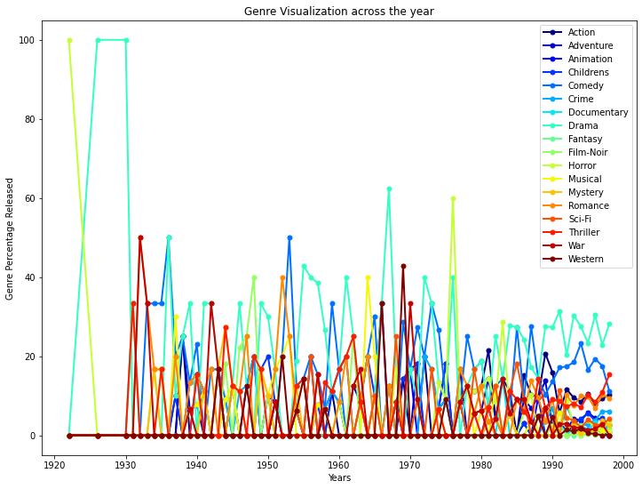

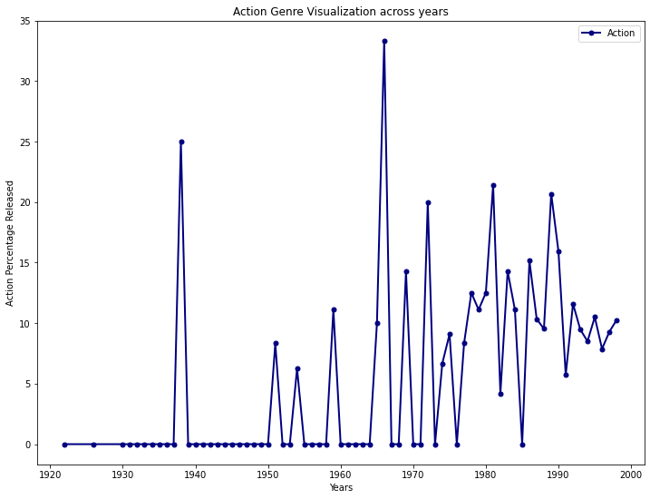

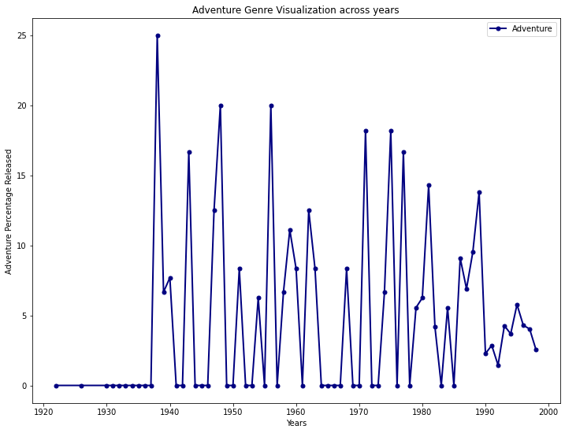

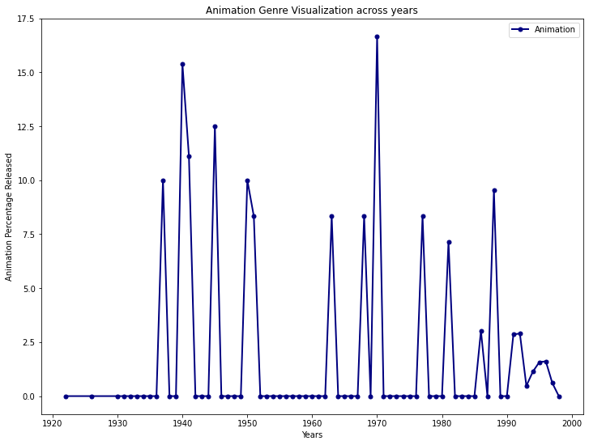

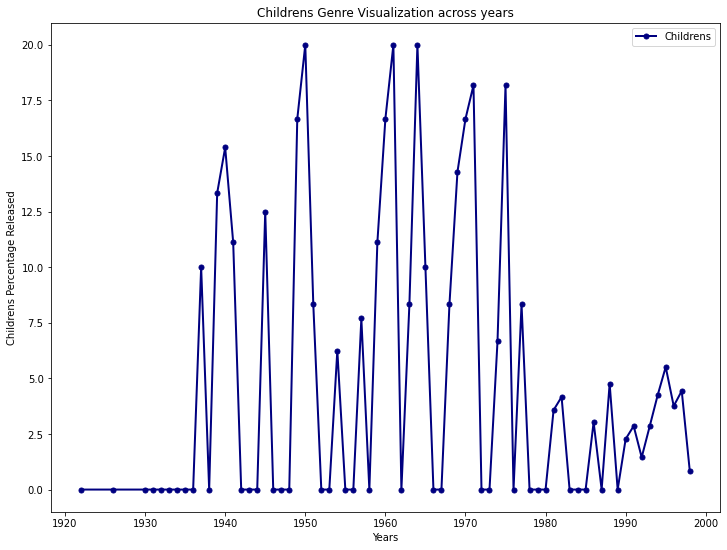

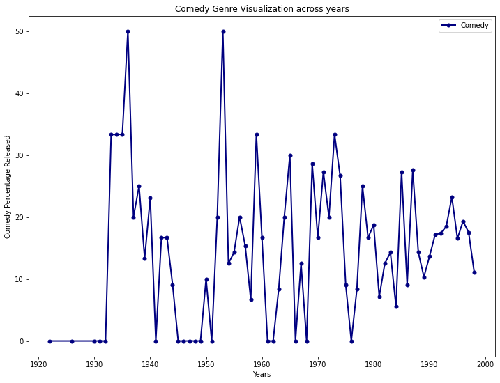

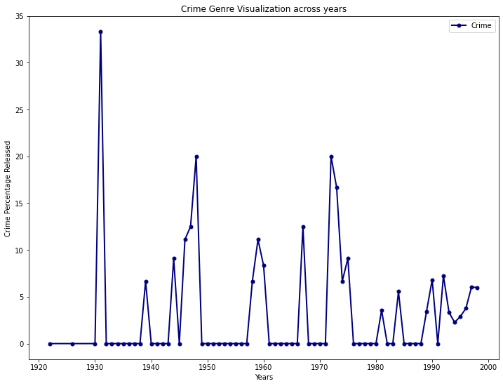

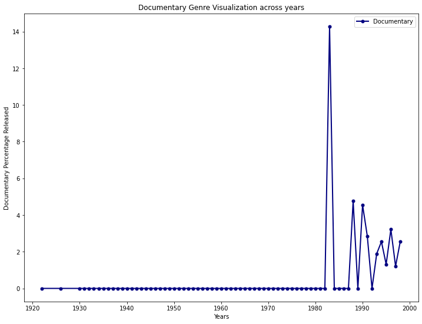

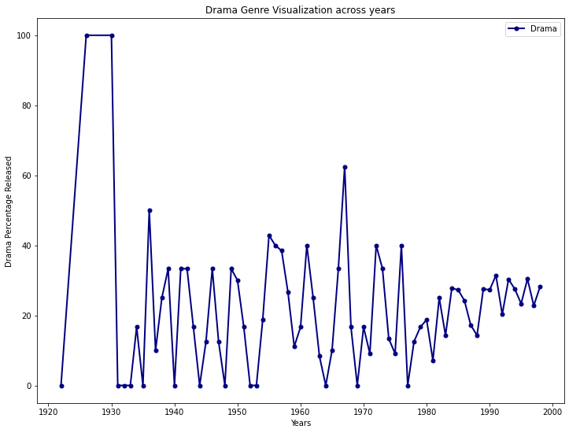

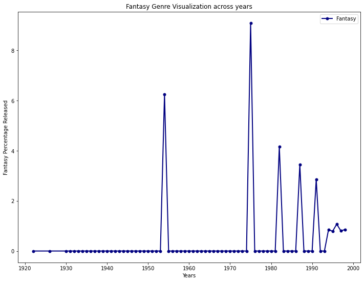

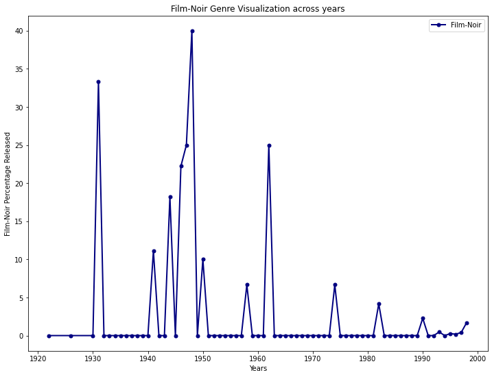

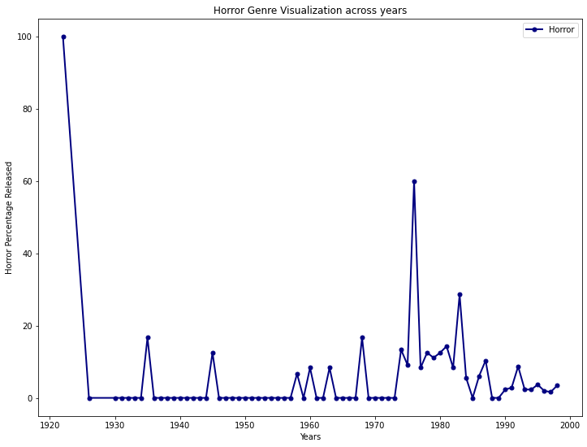

[7 more figures not shown]

```python
# Multi Variant Genre Visualization in same plot
plt.rcParams["figure.figsize"] = [12, 9]
ax = itemdf4.plot(x='release_year', y=['Action', 'Adventure', 'Animation', 'Childrens',
       'Comedy', 'Crime', 'Documentary', 'Drama', 'Fantasy', 'Film-Noir',
       'Horror', 'Musical', 'Mystery', 'Romance', 'Sci-Fi', 'Thriller', 'War',
       'Western'],title= "Genre Visualization across the year",lw=2,
          colormap='jet',
          marker='.',
          markersize=10,)
ax.set_xlabel('Years')
ax.set_ylabel('Genre Percentage Released')


# Univariant Genre Visualization in individual Plot

for genre in ['Action', 'Adventure', 'Animation', 'Childrens',
       'Comedy', 'Crime', 'Documentary', 'Drama', 'Fantasy', 'Film-Noir',
       'Horror', 'Musical', 'Mystery', 'Romance', 'Sci-Fi', 'Thriller', 'War',
       'Western']:
    ax = itemdf4.plot(x='release_year', y=genre,title='%s Genre Visualization across years'%genre,lw=2,
          colormap='jet',
          marker='.',
          markersize=10)
    ax.set_xlabel('Years')
    ax.set_ylabel("%s Percentage Released"%genre)
```

**Insights:**

### 9. Find the top 25 movies in terms of average ratings for movies that have been rated more than 100 times - 10 marks

Hints :

1. Find the count of ratings and average ratings for every movie.
2. Slice the movies which have ratings more than 100.
3. Sort values according to average rating such that movie which highest rating is on top.
4. Select top 25 movies.
5. You will have to use the .merge() function to get the movie titles.

Note: This question will need you to research about groupby and apply your findings. You can find more on groupby on https://realpython.com/pandas-groupby/.

```python
dataItemDF.rename(columns={'movie title' : 'movie_title','movie id': 'movie_id'},inplace=True)
dataItemDF2 = dataItemDF[['movie_title','movie_id','rating']]


# Getting Count on number of rating and flattening into dataframe
d1 = dataItemDF2.groupby('movie_title').count()['rating'].sort_values(ascending=False)
d1_flat = d1.reset_index()
# print(d1_flat)

# Getting average on ratings and flattening into dataframe
d2 = dataItemDF.groupby('movie_title').mean()['rating'].sort_values(ascending=False)
d2_flat = d2.reset_index()
# print(d2_flat)

# Merging the two data frame on movie titke and doing union and renaming the column names
dataItemDF3 = pd.merge(d1_flat,d2_flat,on='movie_title',how='outer')
dataItemDF3.rename(columns={'rating_x': 'count_on_rating','rating_y': 'average_rating'},inplace=True)

# Filtering movies which have more than 100 ratings
dataItemDF4 = dataItemDF3[dataItemDF3['count_on_rating']>100]

# Sorting average rating and getiing top 25
dataItemDF5 = dataItemDF4.sort_values('average_rating',ascending=False).head(25)

# Resetting the index and presenting as dataframe
dataItemDF5.reset_index(inplace=True)
dataItemDF5.drop('index',axis=1,inplace=True)
dataItemDF5
```

|  | movie_title | count_on_rating | average_rating |
| --- | --- | --- | --- |
| 0 | Close Shave, A | 112 | 4.491071 |
| 1 | Schindler's List | 298 | 4.466443 |
| 2 | Wrong Trousers, The | 118 | 4.466102 |
| 3 | Casablanca | 243 | 4.456790 |
| 4 | Shawshank Redemption, The | 283 | 4.445230 |
| 5 | Rear Window | 209 | 4.387560 |
| 6 | Usual Suspects, The | 267 | 4.385768 |
| 7 | Star Wars | 583 | 4.358491 |
| 8 | 12 Angry Men | 125 | 4.344000 |
| 9 | Citizen Kane | 198 | 4.292929 |
| 10 | To Kill a Mockingbird | 219 | 4.292237 |
| 11 | One Flew Over the Cuckoo's Nest | 264 | 4.291667 |
| 12 | Silence of the Lambs, The | 390 | 4.289744 |
| 13 | North by Northwest | 179 | 4.284916 |
| 14 | Godfather, The | 413 | 4.283293 |
| 15 | Secrets & Lies | 162 | 4.265432 |
| 16 | Good Will Hunting | 198 | 4.262626 |
| 17 | Manchurian Candidate, The | 131 | 4.259542 |
| 18 | Dr. Strangelove or: How I Learned to Stop Worr... | 194 | 4.252577 |
| 19 | Raiders of the Lost Ark | 420 | 4.252381 |
| 20 | Vertigo | 179 | 4.251397 |
| 21 | Titanic | 350 | 4.245714 |
| 22 | Lawrence of Arabia | 173 | 4.231214 |
| 23 | Maltese Falcon, The | 138 | 4.210145 |
| 24 | Empire Strikes Back, The | 367 | 4.204360 |

### 10. Check for the validity of the below statements with respect to the data provided - 10 marks

- Men watch more drama than women
- Women watch more Sci-Fi than men
- Men watch more Romance than women

**compare the percentages**

**Please pay attention to what should be the denominator while calculating percentages**

1. Merge all the datasets
2. There is no need to conduct statistical tests around this. Just **compare the percentages** and comment on the validity of the above statements.
3. you might want ot use the .sum(), .div() function here.
4. Use number of ratings to validate the numbers. For example, if out of 4000 ratings received by women, 3000 are for drama, we will assume that 75% of the women watch drama.

```python
# Note : Answer Span in +3 below cells to show plot.

# userDataItemDF is an combined dataframe. By gender we are summing each genre of movies

genderRatingDF = userDataItemDF[['Action', 'Adventure', 'Animation', 'Childrens',
       'Comedy', 'Crime', 'Documentary', 'Drama', 'Fantasy', 'Film-Noir',
       'Horror', 'Musical', 'Mystery', 'Romance', 'Sci-Fi', 'Thriller', 'War',
       'Western','gender']].groupby(['gender']).sum()

# Given a gender adding all genre to get total.

genderRatingDF['total'] = genderRatingDF[['Action', 'Adventure', 'Animation', 'Childrens',
       'Comedy', 'Crime', 'Documentary', 'Drama', 'Fantasy', 'Film-Noir',
       'Horror', 'Musical', 'Mystery', 'Romance', 'Sci-Fi', 'Thriller', 'War',
       'Western']].sum(axis=1)

# Resetting data frame to move gender from index to column
genderRatingDF.reset_index(inplace=True)

# Creating Result Dataframe and calculating the percentage of
resultInPercentDF = genderRatingDF[['gender']]
for genre in ['Action', 'Adventure', 'Animation', 'Childrens',
       'Comedy', 'Crime', 'Documentary', 'Drama', 'Fantasy', 'Film-Noir',
       'Horror', 'Musical', 'Mystery', 'Romance', 'Sci-Fi', 'Thriller', 'War',
       'Western']:
    resultInPercentDF[genre] = genderRatingDF[genre].div(genderRatingDF['total'],axis=0) * 100





print("+++++++++++++++ Below Data Frame is all in percentage")

resultInPercentDF
```

```
+++++++++++++++ Below Data Frame is all in percentage
```

|  | gender | Action | Adventure | Animation | Childrens | Comedy | Crime | Documentary | Drama | Fantasy | Film-Noir | Horror | Musical | Mystery | Romance | Sci-Fi | Thriller | War | Western |
| --- | --- | --- | --- | --- | --- | --- | --- | --- | --- | --- | --- | --- | --- | --- | --- | --- | --- | --- | --- |
| 0 | F | 10.133889 | 5.849053 | 1.852852 | 4.156347 | 15.023929 | 3.340720 | 0.348224 | 20.498687 | 0.675965 | 0.716933 | 2.229009 | 2.685239 | 2.446882 | 10.908549 | 4.895626 | 9.47096 | 4.076274 | 0.690862 |
| 1 | M | 12.680320 | 6.679087 | 1.642708 | 3.115480 | 13.698044 | 3.940611 | 0.359382 | 18.181189 | 0.622467 | 0.848418 | 2.593087 | 2.210418 | 2.474132 | 8.561592 | 6.357468 | 10.56494 | 4.537272 | 0.933385 |

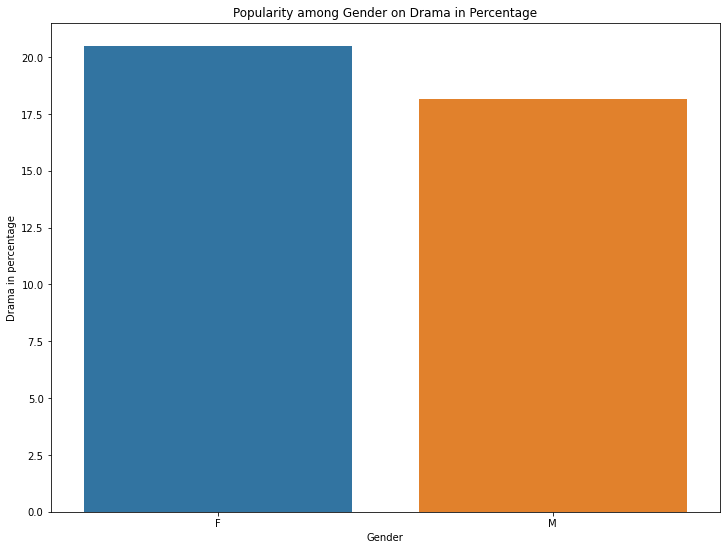

```python
ax = sns.barplot(resultInPercentDF['gender'],resultInPercentDF['Drama']).set_title("Popularity among Gender on Drama in Percentage")
plt.xlabel("Gender")
plt.ylabel("Drama in percentage")
# plt.show(ax)
```

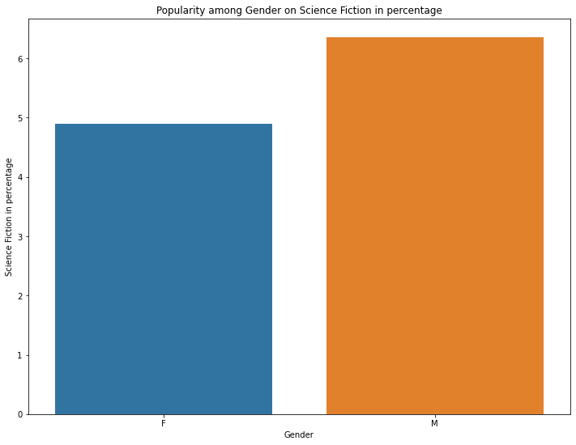

```python
sns.barplot(resultInPercentDF['gender'],resultInPercentDF['Sci-Fi']).set_title("Popularity among Gender on Science Fiction in percentage")
plt.xlabel("Gender")
plt.ylabel("Science Fiction in percentage")
```

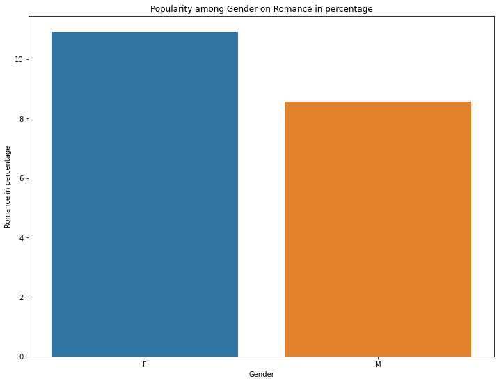

```python
sns.barplot(resultInPercentDF['gender'],resultInPercentDF['Romance']).set_title("Popularity among Gender on Romance in percentage")
plt.xlabel("Gender")
plt.ylabel("Romance in percentage")
```

**Conclusion:**

1. Dramas are more popular among women(20.49%) than men(18.18%).
2. Men(6.3%) watches for more Science Fiction than women(4.8%)
3. Women(10.90%) watches more Romance than Men(8.56%)

Hence all three below verification are False

- Men watch more drama than women
- Women watch more Sci-Fi than men
- Men watch more Romance than women